# Data-Dive : GLMs

Lets consider the - - **Response variable = Profit** - **Explanatory Variable = Sales**

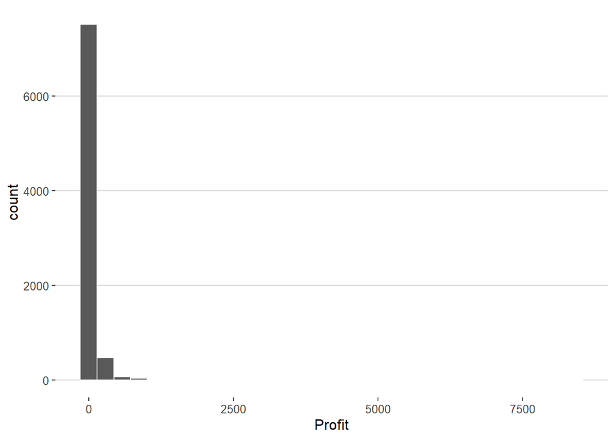

```r
Superstore_binary |>
  filter(Profit >=0)|>
  ggplot(mapping = aes(x = Profit)) +
  geom_histogram(color = 'white') +
  labs("Histogram of Profit ") +
  theme_hc()
```

For example, Profit (or, positive dollar amounts in general) typically resembles slightly a Poisson distribution. Therefore we further try to do a log over Profit to view the data better. Also, trying to check only on profits and not losses hence filter condition of Profit >= 0.

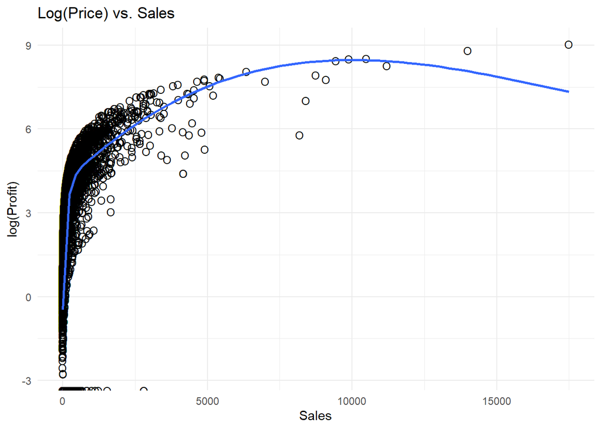

```r
Superstore_binary |>
  filter(Profit >=0) |>
  ggplot(mapping = aes(x = Sales, y = log(Profit))) +
  geom_point(shape = 'O', size = 3) +
  geom_smooth(se = FALSE) +
  labs(title = "Log(Price) vs. Sales") +
  theme_minimal()
```

- From the above graph, it doesnt seem like a great idea of doing a log over Profit.It just messes the data more. Hence trying to do transformation on explanatory variable i.e. Sales.
- But first will plot the variables to understand their nature.

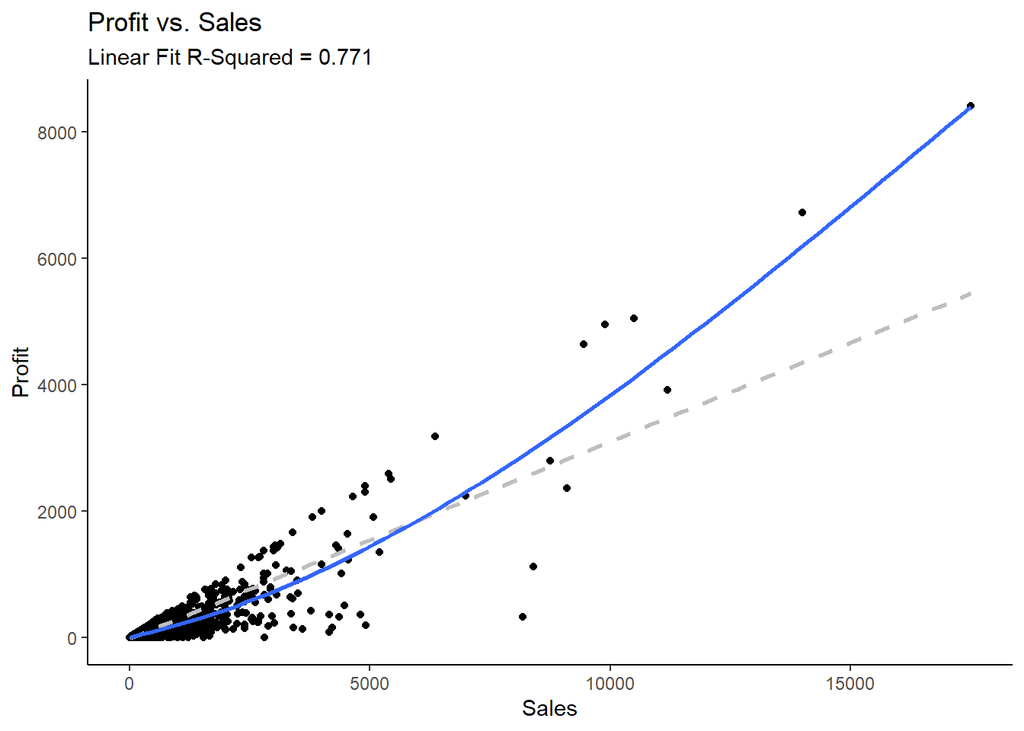

```r
model <- lm(Profit ~ Sales,
            filter(Superstore_binary, Profit >=0))



rsquared <- summary(model)$r.squared

    Superstore_binary |>
      filter(Profit >=0) |>
  ggplot(mapping = aes(x = Sales,
                       y = Profit)) +
  geom_point() +
  geom_smooth(method = 'lm', color = 'gray', linetype = 'dashed',
              se = FALSE) +
  geom_smooth(se = FALSE) +
  labs(title = "Profit vs. Sales",
       subtitle = paste("Linear Fit R-Squared =", round(rsquared, 3))) +
  theme_classic()
```

There is a clear monotonic relationship between $x$ (sales) and $y$ (profit) here, “as $x$ increases, $y$ increases.” In this case the relationship is quadratic, so $y$ could be modeled non-linearly as=
$$y = ax^2 + bx + c + \varepsilon$$

From the plot, we could also determine that the there is a quadratic relation between (x)Sales and (y)Profit. Further transforming the (sales)explanatory variable to create an effective regressive model and plotting the same.

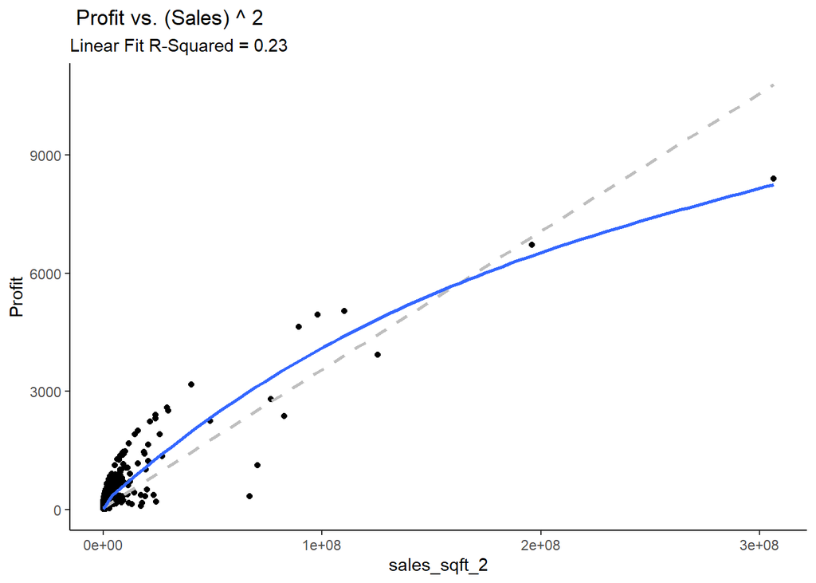

```r
Superstore_binary_filt <- Superstore_binary |>
  mutate(sales_sqft_2 = Sales ^ 2)  # add new variable

model <- lm(Profit ~ sales_sqft_2 + Sales,
            filter(Superstore_binary_filt))

rsquared <- summary(model)$r.squared

Superstore_binary_filt |>
      filter(Profit >=1) |>
  ggplot(mapping = aes(x = sales_sqft_2,
                       y = Profit)) +
  geom_point() +
  geom_smooth(method = 'lm', color = 'gray', linetype = 'dashed',
              se = FALSE) +
  geom_smooth(se = FALSE) +
  labs(title = " Profit vs. (Sales) ^ 2",
       subtitle = paste("Linear Fit R-Squared =", round(rsquared, 3))) +
  theme_classic()
```